# Session 2: Looking at the SHHS data

## Before you start

Save this notebook under a different name in your `shhs_workshop` folder. That way, you have a backup just in case.

## What is an R Notebook?

An R Notebook is a way to run R code and save the output (such as graphs and tables) in the same document. Make sure that you have opened the project file (`shhs_workshop.rproj`) in RStudio before you do anything. This will set you up so R knows where the data is.

There are two main formats for a R Notebook. The first are known as the *markdown chunks*, which are mostly text, and let you add commentary about your findings. The other format is the *code chunk*, which is started by the three backticks (```) and a `{r}`, such as the code block below. Usually, we want the code block to give us an output, such as a table or a graph. However, the code isn’t run until we hit the play button. This is really important to know.

R Notebooks are presented two ways: as an editable document (which is what you have here), and a preview document. You will be able to see the preview document by hitting the `Preview` button. Try hitting the “Preview” button now.

## Important!

Be sure to go slowly through the notebook slowly and read the code. If you just press play without reading and understanding the code, you will miss out on the learning! Talk about the code blocks with your group partner.

## Getting Help

If you’re confused about a function, such as `head`, you can run `?head` (adding a question mark to the beginning of the function) to get help about that function. Try running the command below by hitting the play button on the top right of the code chunk. The help window for the function should open on the right.

## Our first code block

The grey block below is a *code block*. Try pressing the green play button on the top right. What do you think is going to happen?

```
[1] 13
```

Note that code blocks are defined by using three ` (backticks) and the {r}. All the code is then followed with another three backticks:

# Starting Out

We’re going to start looking at the Sleep Health Heart Study (SHHS) Data. To do so, we first need to:

1. load some software packages to help us explore the data (using the `library()` command), and
2. load the data and data dictionary (using `readRDS()`, which reads in R’s internal data format and `read.csv()`, which reads in a Comma-Separated-Value (`csv`) file.

Execute this code block.

```
here() starts at C:/Code/clinical_data_wrangling
```

# Looking at the tabular form of the data

Our data is loaded as a table (also known as a `data.frame`) into R. A useful command to look at the data in its tabular form is `View()`. Try it out by running the code block below. Another window should pop up and you should see an Excel-like table.

What does each row represent in the data?

# What are our variables and what do they mean?

We can list the column names of our dataset using `colnames`:

```
 [1] "age_s1"      "gender"      "ahi_a0h3"    "ahi_a0h4"
 [5] "oahi"        "race"        "smokstat_s1" "chol"
 [9] "htnderv_s1"  "systbp"      "bmi_s1"      "hdl"
[13] "any_cvd"     "neck20"      "srhype"      "ace1"
[17] "beta1"
```

For us in general, a column represents a *variable*, or some sort of measurement of the dataset. Because each row represents a patient, then the table entry for a row means it’s the observed value of that variable for a particular patient.

But what is in each variable? If we’re lucky, a dataset will come with what is called a *data dictionary*, which has some defintions of each variable in the dataset.

Look up the defintion for `ahi_a0h3` in the data dictionary below - what is the definition? How is it related to Sleep Apnea?

|  | folder | id | display_name | description | type | units | domain | labels | calculation | commonly_used | forms |
| --- | --- | --- | --- | --- | --- | --- | --- | --- | --- | --- | --- |
| 1 | Administrative | ecg | Has electrocardiogram (ECG) data (Sleep Heart Health Study Visit One (SHHS1)) |  | choices |  | noyes01 | ekg |  |  |  |
| 2 | Administrative | shhs1_ae | Has Sleep Heart Health Study Visit One (SHHS1) Adverse Event form |  | choices |  | noyes01 |  |  |  |  |
| 3 | Administrative | shhs1_all | Has all Sleep Heart Health Study Visit One (SHHS1) forms |  | choices |  | noyes01 |  |  |  |  |
| 4 | Administrative | shhs1_avars | Has Sleep Heart Health Study Visit One (SHHS1) A-variables |  | choices |  | noyes01 |  |  |  |  |
| 5 | Administrative | shhs1_bp | Has Sleep Heart Health Study Visit One (SHHS1) Blood Pressure (BP) form |  | choices |  | noyes01 |  |  |  |  |
| 6 | Administrative | shhs1_cf | Has Sleep Heart Health Study Visit One (SHHS1) Contact form |  | choices |  | noyes01 |  |  |  |  |
| 7 | Administrative | shhs1_hi | Has Sleep Heart Health Study Visit One (SHHS1) Health Interview form |  | choices |  | noyes01 |  |  |  |  |
| 8 | Administrative | shhs1_meds | Has Sleep Heart Health Study Visit One (SHHS1) Medications form |  | choices |  | noyes01 |  |  |  |  |
| 9 | Administrative | shhs1_ms | Has Sleep Heart Health Study Visit One (SHHS1) Morning Survey form |  | choices |  | noyes01 |  |  |  |  |
| 10 | Administrative | shhs1_psg | Has Sleep Heart Health Study Visit One (SHHS1) Polysomnography (PSG) record |  | choices |  | noyes01 |  |  |  |  |

[output cut: 1981 more lines]

# Running `burro` on our dataset

When you want to continue on in the notebook, be sure to hit the red stop button on the top right of the code block. We’ll include code blocks to open `burro` throughout the notebook to avoid scrolling.

```
Listening on http://127.0.0.1:5492
```

```
NA
```

# The Overview Panel

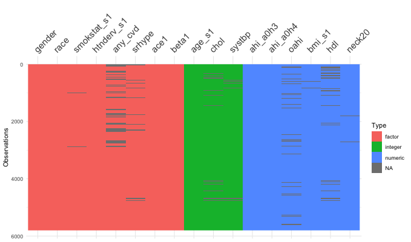

# Some Questions for the Overview Panel (5-10 minutes)

As a group, take a look at the following questions and attempt to answer them from the overview panel.

As you do, take a note of which tab (`Visual Summary`, `Tabular Summary`, and `Data Dictionary`) you found the information in.

Be sure to use your post-it notes if you’re confused or need help!

1. How big is the dataset? (how many rows?)
2. How many categorical variables (also called `factor`s) are there in our dataset?
3. How many missing Cardiovascular Disease Cases (coded as `NA`) are there?
4. What is the mean age for the dataset? Is it what you expected?
5. How is the `oahi` variable calculated?

```
Listening on http://127.0.0.1:4689
```

```
NA
```

# The Category Panel

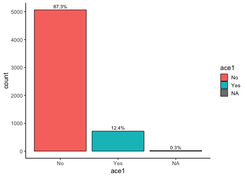

# Some Questions for the Category Panel (5-10 minutes)

Again, answer these as a group!

6. How many categories are there for `race`?
7. Are the proportions of cvd cases balanced across `race`?
8. If you are `male`, are you more likely to have cardiovascular disease?
9. Is the proportion of missing data for `any_cvd` balanced across `race` categories?

# The Continuous Panel

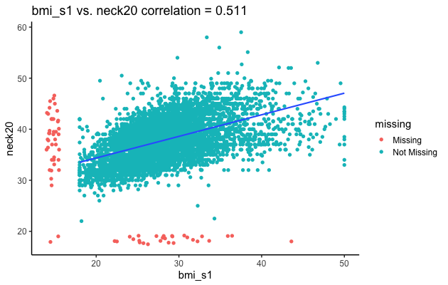

# Some Questions for the Continuous Panel (5-10 minutes)

10. As you get older, are you more likely to have CVD?
11. Is `age_s1` evenly distributed across `race`? If not, how are they distributed?
12. Are `bmi_s1` and `neck20` correlated? Why do you think that’s the case?
13. Is `bmi_s1` associated with `any_cvd`? Are you surprised?
14. Should we include both `bmi_s1` and `neck20` in our dataset?

# Subsetting using `filter()`

What if we’re interested in a particular group, such as only `Female`s?

We can use the `filter()` command from the `dplyr` package to *subset* the data to that group, and then use `explore_data()`.

Be careful that the values for your variable match your filter statement. For example, for `gender`, note that the values are (`Female`, `Male`) instead of (`F`,`M`) or (`female`, `male`). The capitalization, or Case is important.

Here we’re using `filter()` to select only `Female` patients in the dataset.

Try out subsetting the data by copying the code block above.